# Cyclistic Bike-Share Analysis: Converting Casual Riders to Members

ASEGID AYELE

2025-08-03

# 1 Cyclistic Bike-Share Capstone Project

Welcome to my data analysis capstone project for Cyclistic, a fictional bike-share company in Chicago. This report follows the **Ask, Prepare, Process, Analyze, Share, Act** framework to answer a key business question:

**How do annual members and casual riders use Cyclistic bikes differently?**

This analysis aims to inform a targeted marketing strategy to convert casual riders into annual members, supporting Cyclistic’s long-term profitability.

## 1.1 1. Ask: Define the Business Task

### 1.1.1 Business Objective

The primary objective is to analyze historical trip data to identify behavioral differences between casual riders (pay-per-ride or day-pass users) and annual members (subscribers). These insights will then be used to design and propose a targeted marketing strategy aimed at converting casual riders into annual members.

### 1.1.2 Key Questions

To achieve the business objective, the analysis will address the following key questions:

- How do ride frequency, duration, and timing differ between user types?
- Are members more likely to use bikes for commuting (weekdays)? Do casual riders prefer weekends?
- Are there seasonal or daily trends in usage patterns for each user type?

### 1.1.3 Stakeholders

This project is being conducted for **Lily Moreno, the Director of Marketing** at Cyclistic. Her team is responsible for designing the new marketing strategy. The **Cyclistic Executive Team** will need to approve the recommendations, emphasizing the need for compelling data insights and professional visualizations. Other key stakeholders include the **Marketing Analytics Team**.

## 1.2 2. Prepare: Data Sources

### 1.2.1 Dataset Overview

- **Source**: Divvy Trip Data (public dataset, used as proxy for Cyclistic)
- **Time Period**: Q1 2019 and Q1 2020 (January–March)
- **Files Used**:
  - `Divvy_Trips_2019_Q1.csv`
  - `Divvy_Trips_2020_Q1.csv`
- **Key Variables**: `trip_id`, `start_time`, `end_time`, `bike_type`, `usertype` (“Subscriber” or “Customer”)

### 1.2.2 ROCCC Analysis

| CRITERION | ASSESSMENT |
| --- | --- |
| Reliability | High - official data from Motivate Intl. Inc. |
| Original | Yes - primary source |
| Comprehensive | Moderate - lacks user demographics due to privacy |
| Current | Historical, but sufficient for trend analysis |
| Cited | Yes - [licensed under Divvy’s Data License Agreement](https://www.divvybikes.com/data-license-agreement) |

🔒 **Note**: No personally identifiable information (PII) is available.

### 1.2.3 Data Loading and Initial Inspection

```r
# Load necessary libraries
library(tidyverse) # For data manipulation and visualization (ggplot2, dplyr)
library(lubridate) # For working with dates and times
library(scales) # For formatting numbers in plots
library(janitor) # For cleaning column names

# Set default ggplot2 theme for better aesthetics and a clean, professional look
theme_set(theme_light())
```

```r
# Load raw data from the specified CSV files.
# The file paths are adjusted to correctly point to the `data/` subfolder.
# The `../` navigates up one directory from your RMD file's location.
trips_2019 <- read_csv("../data/Divvy_Trips_2019_Q1.csv", show_col_types = FALSE)
trips_2020 <- read_csv("../data/Divvy_Trips_2020_Q1.csv", show_col_types = FALSE)

# Clean column names for easier access using janitor::clean_names()
trips_2019 <- clean_names(trips_2019)
trips_2020 <- clean_names(trips_2020)

# Standardize column names across both datasets to ensure consistency before combining.
# 'start_time' becomes 'started_at'
# 'end_time' becomes 'ended_at'
# 'usertype' becomes 'member_casual'
trips_2019 <- trips_2019 %>%
  rename(
    started_at = start_time,
    ended_at = end_time,
    member_casual = usertype
  )

# Combine datasets into a single data frame.
# bind_rows is used to handle potential column inconsistencies gracefully.
all_trips <- bind_rows(trips_2019, trips_2020)

# Display a summary of the combined data
glimpse(all_trips)
```

```
## Rows: 791,956
## Columns: 22
## $ trip_id            <dbl> 21742443, 21742444, 21742445, 21742446, 21742447, 2…
## $ started_at         <dttm> 2019-01-01 00:04:37, 2019-01-01 00:08:13, 2019-01-…
## $ ended_at           <dttm> 2019-01-01 00:11:07, 2019-01-01 00:15:34, 2019-01-…
## $ bikeid             <dbl> 2167, 4386, 1524, 252, 1170, 2437, 2708, 2796, 6205…
## $ tripduration       <dbl> 390, 441, 829, 1783, 364, 216, 177, 100, 1727, 336,…
## $ from_station_id    <dbl> 199, 44, 15, 123, 173, 98, 98, 211, 150, 268, 299, …
## $ from_station_name  <chr> "Wabash Ave & Grand Ave", "State St & Randolph St",…
## $ to_station_id      <dbl> 84, 624, 644, 176, 35, 49, 49, 142, 148, 141, 295, …
## $ to_station_name    <chr> "Milwaukee Ave & Grand Ave", "Dearborn St & Van Bur…
## $ member_casual      <chr> "Subscriber", "Subscriber", "Subscriber", "Subscrib…
## $ gender             <chr> "Male", "Female", "Female", "Male", "Male", "Female…
## $ birthyear          <dbl> 1989, 1990, 1994, 1993, 1994, 1983, 1984, 1990, 199…
## $ ride_id            <chr> NA, NA, NA, NA, NA, NA, NA, NA, NA, NA, NA, NA, NA,…
## $ rideable_type      <chr> NA, NA, NA, NA, NA, NA, NA, NA, NA, NA, NA, NA, NA,…
## $ start_station_name <chr> NA, NA, NA, NA, NA, NA, NA, NA, NA, NA, NA, NA, NA,…
## $ start_station_id   <dbl> NA, NA, NA, NA, NA, NA, NA, NA, NA, NA, NA, NA, NA,…
## $ end_station_name   <chr> NA, NA, NA, NA, NA, NA, NA, NA, NA, NA, NA, NA, NA,…
## $ end_station_id     <dbl> NA, NA, NA, NA, NA, NA, NA, NA, NA, NA, NA, NA, NA,…
## $ start_lat          <dbl> NA, NA, NA, NA, NA, NA, NA, NA, NA, NA, NA, NA, NA,…
## $ start_lng          <dbl> NA, NA, NA, NA, NA, NA, NA, NA, NA, NA, NA, NA, NA,…
## $ end_lat            <dbl> NA, NA, NA, NA, NA, NA, NA, NA, NA, NA, NA, NA, NA,…
## $ end_lng            <dbl> NA, NA, NA, NA, NA, NA, NA, NA, NA, NA, NA, NA, NA,…
```

## 1.3 3. Process: Data Cleaning and Transformation

This section details the steps taken to clean and transform the raw data into a format suitable for analysis.

```r
# Handle missing values in critical columns.
# Rows with missing 'started_at', 'ended_at', or 'member_casual' are removed
# as these are essential for the analysis.
all_trips <- all_trips %>%
  filter(!is.na(started_at), !is.na(ended_at), !is.na(member_casual))

# Convert datetime columns to appropriate formats for accurate time calculations.
all_trips <- all_trips %>%
  mutate(
    started_at = ymd_hms(started_at),
    ended_at = ymd_hms(ended_at)
  )
```

```r
# Create derived variables that will be used for analyzing temporal patterns and ride characteristics.
all_trips <- all_trips %>%
  mutate(
    # Calculate ride_length in minutes.
    ride_length = as.numeric(difftime(ended_at, started_at, units = "mins")),
    # Extract day of week. 'week_start = 1' sets Monday as the first day.
    day_of_week = wday(started_at, label = TRUE, abbr = FALSE, week_start = 1),
    # Extract month.
    month = month(started_at, label = TRUE, abbr = FALSE),
    # Extract year.
    year = year(started_at),
    # Extract hour of day for hourly trend analysis
    hour_of_day = hour(started_at)
  )

# Recode 'member_casual' to unified labels ('Subscriber' -> 'member', 'Customer' -> 'casual')
# and convert to a factor with specified levels for consistent plotting.
all_trips <- all_trips %>%
  mutate(
    member_casual = recode(member_casual,
                           "Subscriber" = "member",
                           "Customer" = "casual"),
    member_casual = factor(member_casual, levels = c("member", "casual")),
    # Ensure day_of_week is a factor with correct order for chronological plotting.
    day_of_week = factor(day_of_week, levels = c("Monday", "Tuesday", "Wednesday", "Thursday", "Friday", "Saturday", "Sunday"))
  )
```

```r
# Remove bad data: rides less than 1 minute or greater than 24 hours (1440 minutes).
# Rides that are extremely short or long are likely errors or test rides and can skew the analysis.
all_trips <- all_trips %>%
  filter(ride_length > 1, ride_length < 1440)
```

```r
# Select only the relevant columns for the final analysis and display a summary.
all_trips <- all_trips %>%
  select(started_at, ended_at, member_casual, ride_length, day_of_week, month, year, hour_of_day)
glimpse(all_trips)
```

```
## Rows: 783,778
## Columns: 8
## $ started_at    <dttm> 2019-01-01 00:04:37, 2019-01-01 00:08:13, 2019-01-01 00…
## $ ended_at      <dttm> 2019-01-01 00:11:07, 2019-01-01 00:15:34, 2019-01-01 00…
## $ member_casual <fct> member, member, member, member, member, member, member, …
## $ ride_length   <dbl> 6.500000, 7.350000, 13.816667, 29.716667, 6.066667, 3.60…
## $ day_of_week   <ord> Tuesday, Tuesday, Tuesday, Tuesday, Tuesday, Tuesday, Tu…
## $ month         <ord> January, January, January, January, January, January, Ja…
## $ year          <dbl> 2019, 2019, 2019, 2019, 2019, 2019, 2019, 2019, 2019, 20…
## $ hour_of_day   <int> 0, 0, 0, 0, 0, 0, 0, 0, 0, 0, 0, 0, 0, 0, 0, 0, 0, 0, 0,…
```

```r
summary(all_trips$ride_length)
```

```
##     Min.  1st Qu.   Median     Mean  3rd Qu.     Max.
##    1.017    5.550    9.033   13.790   15.233 1435.917
```

### 1.3.1 Cleaning Steps Summary

- Cleaned and standardized column names (`janitor::clean_names`).
- Renamed inconsistent columns (`start_time`, `end_time`, `usertype`) across Q1 2019 and 2020 datasets to `started_at`, `ended_at`, and `member_casual` respectively.
- Removed rows with missing or malformed date/time or rider type entries.
- Converted start/end time to `POSIXct` datetime objects.
- Calculated derived variables: `ride_length` (in minutes), `day_of_week`, `month`, `year`, and `hour_of_day`.
- Re-labeled `usertype` values (“Subscriber” and “Customer”) to unified `member_casual` labels (“member” and “casual”) and converted to a factor.
- Removed rides with unrealistic or invalid durations (less than 1 minute or over 24 hours).
- Dropped unrelated or unused columns to streamline the dataset.
- Verified factor order for `day_of_week` and `member_casual` for consistent plotting.

✅ The dataset is now cleaned and ready for analysis.

## 1.4 4. Analyze: Data Exploration and Visualization

This section focuses on exploring the cleaned data to uncover patterns and differences between casual riders and annual members.

### 1.4.1 Key Data Summaries

Let’s start by looking at some summary statistics for ride length and overall rider distribution.

```r
# Total number of rides
total_rides <- nrow(all_trips)
cat("Total number of rides:", total_rides, "\n\n")
```

```
## Total number of rides: 783778
```

```r
# Number of casual riders vs. members
rider_distribution <- all_trips %>%
  group_by(member_casual) %>%
  summarise(count = n()) %>%
  mutate(percentage = count / sum(count) * 100)

print(rider_distribution)
```

```
## # A tibble: 2 × 3
##   member_casual  count percentage
##   <fct>          <int>      <dbl>
## 1 member        716381      91.4
## 2 casual         67397       8.60
```

```r
cat("\n")
```

```r
# Average ride length for casual vs. members
avg_ride_length <- all_trips %>%
  group_by(member_casual) %>%
  summarise(mean_ride_length_mins = mean(ride_length))

print(avg_ride_length)
```

```
## # A tibble: 2 × 2
##   member_casual mean_ride_length_mins
##   <fct>                         <dbl>
## 1 member                         11.5
## 2 casual                         38.5
```

```r
cat("\n")
```

```r
# Max ride length for casual vs. members
max_ride_length <- all_trips %>%
  group_by(member_casual) %>%
  summarise(max_ride_length_mins = max(ride_length))

print(max_ride_length)
```

```
## # A tibble: 2 × 2
##   member_casual max_ride_length_mins
##   <fct>                        <dbl>
## 1 member                       1433.
## 2 casual                       1436.
```

# 2 Visualizations

## 2.1 Ride Length Distribution by Rider Type

### 2.1.1 This histogram visualizes the distribution of ride lengths for both casual riders and members, highlighting the difference in typical ride durations.

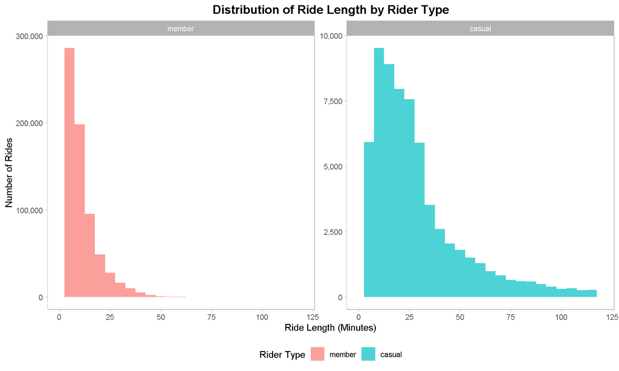

```r
# Create the plot and assign it to a variable
p_ride_length_dist <- all_trips %>%
  ggplot(aes(x = ride_length, fill = member_casual)) +
  geom_histogram(binwidth = 5, position = "identity", alpha = 0.7) +
  facet_wrap(~member_casual, scales = "free_y") +
  labs(
    title = "Distribution of Ride Length by Rider Type",
    x = "Ride Length (Minutes)",
    y = "Number of Rides",
    fill = "Rider Type"
  ) +
  scale_x_continuous(limits = c(0, 120)) + # Focus on rides up to 120 minutes for clarity
  scale_y_continuous(labels = comma) +
  theme_light() +
  theme(
    legend.position = "bottom",
    panel.grid = element_blank(), # Removes grid lines
    plot.title = element_text(size = 14, face = "bold", hjust = 0.5) # Bolds and centers the title
  )

# Display the plot
print(p_ride_length_dist)
```

```r
# Save the plot to the visualizations folder
# The path is now corrected to navigate up one level from the 'code' folder
ggsave("../visualizations/ride_length_distribution.png", plot = p_ride_length_dist, width = 10, height = 6)
```

## 2.2 Average Ride Length by Day of Week

### 2.2.1 This bar chart compares the average ride duration for casual riders and members across different days of the week.

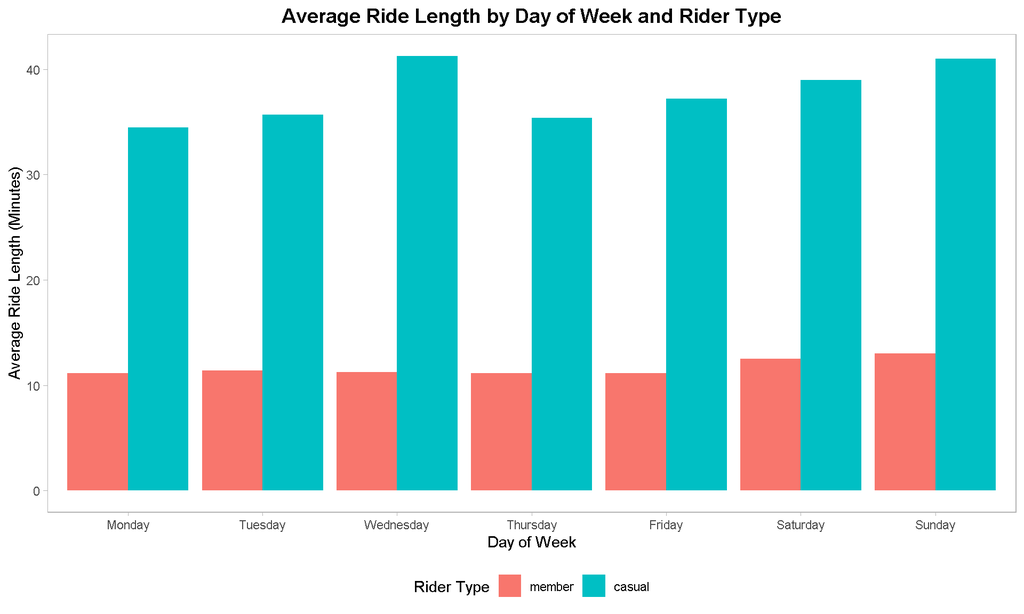

```r
# Create the plot and assign it to a variable
p_avg_ride_length_day <- all_trips %>%
  group_by(member_casual, day_of_week) %>%
  summarise(average_ride_length = mean(ride_length), .groups = 'drop') %>%
  ggplot(aes(x = day_of_week, y = average_ride_length, fill = member_casual)) +
  geom_col(position = "dodge") +
  labs(
    title = "Average Ride Length by Day of Week and Rider Type",
    x = "Day of Week",
    y = "Average Ride Length (Minutes)",
    fill = "Rider Type"
  ) +
  theme_light() +
  theme(
    legend.position = "bottom",
    panel.grid = element_blank(), # Removes grid lines
    plot.title = element_text(size = 14, face = "bold", hjust = 0.5) # Bolds and centers the title
  )

# Display the plot
print(p_avg_ride_length_day)
```

```r
# Save the plot to the visualizations folder
# The path is now corrected to navigate up one level from the 'code' folder
ggsave("../visualizations/avg_ride_length_by_day.png", plot = p_avg_ride_length_day, width = 10, height = 6)
```

## 2.3 Total Rides by Day of Week

### 2.3.1 This plot shows the total number of rides for each day of the week, separated by rider type, revealing peak usage days.

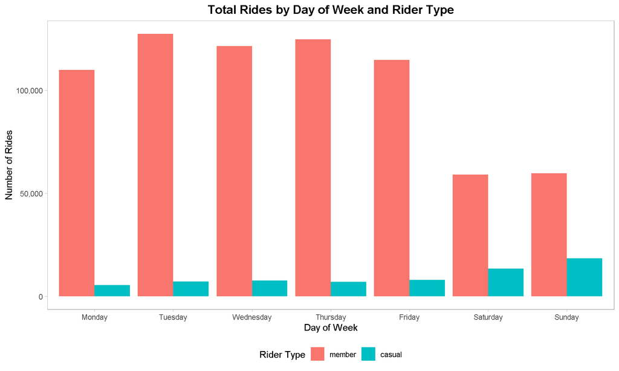

```r
# Create the plot and assign it to a variable
p_total_rides_day_of_week <- all_trips %>%
  group_by(member_casual, day_of_week) %>%
  summarise(number_of_rides = n(), .groups = 'drop') %>%
  ggplot(aes(x = day_of_week, y = number_of_rides, fill = member_casual)) +
  geom_col(position = "dodge") +
  labs(
    title = "Total Rides by Day of Week and Rider Type",
    x = "Day of Week",
    y = "Number of Rides",
    fill = "Rider Type"
  ) +
  scale_y_continuous(labels = comma) +
  theme_light() +
  theme(
    legend.position = "bottom",
    panel.grid = element_blank(), # Removes grid lines
    plot.title = element_text(size = 14, face = "bold", hjust = 0.5) # Bolds and centers the title
  )

# Display the plot
print(p_total_rides_day_of_week)
```

```r
# Save the plot to the visualizations folder
# The path is now corrected to navigate up one level from the 'code' folder
ggsave("../visualizations/total_rides_day_of_week.png", plot = p_total_rides_day_of_week, width = 10, height = 6)
```

## 2.4 Total Rides by Month

### 2.4.1 This chart illustrates the monthly trend in total rides for both casual riders and members, indicating seasonal patterns.

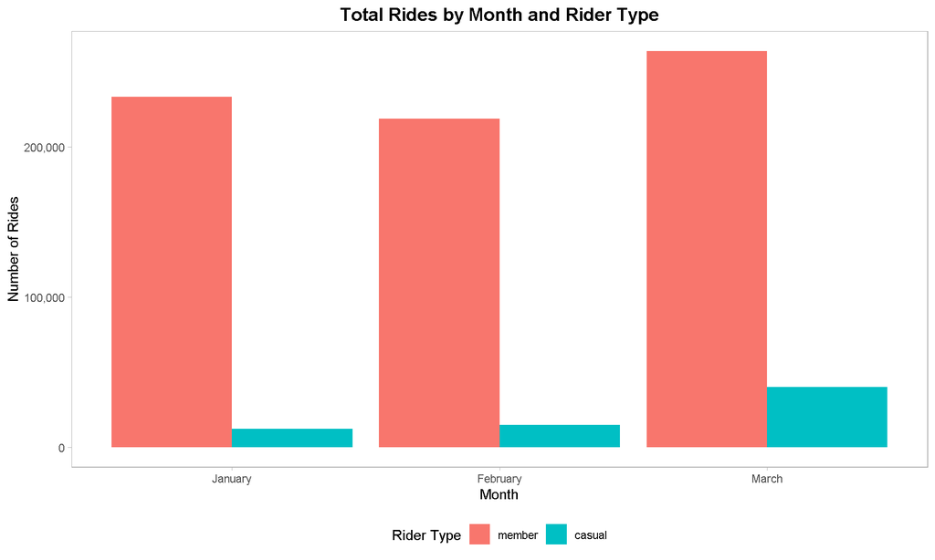

```r
# Create the plot and assign it to a variable
p_total_rides_month <- all_trips %>%
  group_by(member_casual, month) %>%
  summarise(number_of_rides = n(), .groups = 'drop') %>%
  ggplot(aes(x = month, y = number_of_rides, fill = member_casual)) +
  geom_col(position = "dodge") +
  labs(
    title = "Total Rides by Month and Rider Type",
    x = "Month",
    y = "Number of Rides",
    fill = "Rider Type"
  ) +
  scale_y_continuous(labels = comma) +
  theme_light() +
  theme(
    legend.position = "bottom",
    panel.grid = element_blank(), # Removes grid lines
    plot.title = element_text(size = 14, face = "bold", hjust = 0.5) # Bolds and centers the title
  )

# Display the plot
print(p_total_rides_month)
```

```r
# Save the plot to the visualizations folder
# The path is now corrected to navigate up one level from the 'code' folder
ggsave("../visualizations/total_rides_month.png", plot = p_total_rides_month, width = 10, height = 6)
```

## 2.5 Total Rides by Hour of Day

### 2.5.1 This line plot visualizes the hourly distribution of rides, showing peak commuting times versus leisure times.

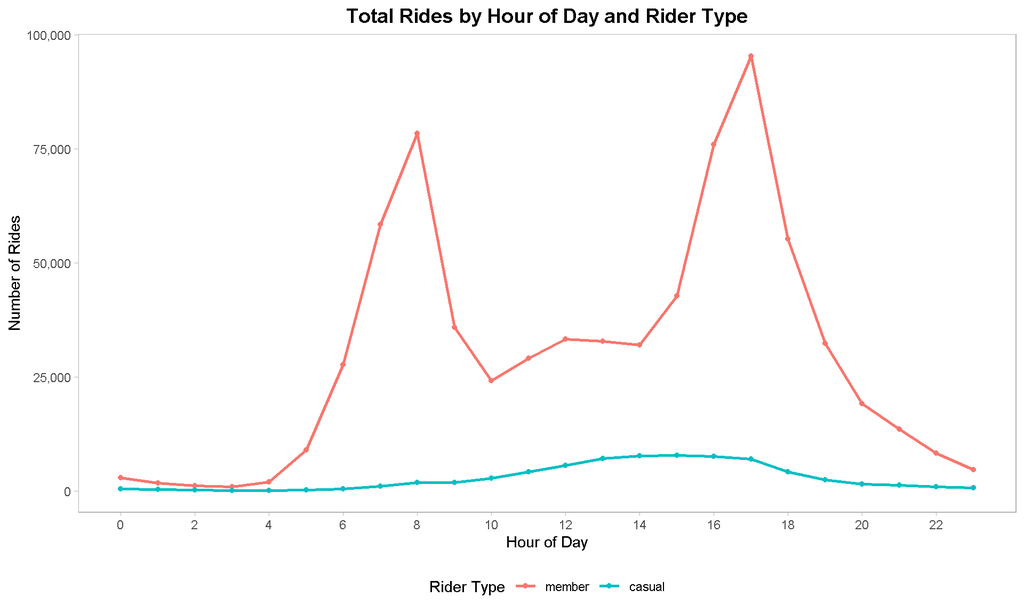

```r
# Create the plot and assign it to a variable
p_total_rides_hour_of_day <- all_trips %>%
  group_by(member_casual, hour_of_day) %>%
  summarise(number_of_rides = n(), .groups = 'drop') %>%
  ggplot(aes(x = hour_of_day, y = number_of_rides, color = member_casual, group = member_casual)) +
  geom_line(linewidth = 1) +
  geom_point() +
  labs(
    title = "Total Rides by Hour of Day and Rider Type",
    x = "Hour of Day",
    y = "Number of Rides",
    color = "Rider Type"
  ) +
  scale_x_continuous(breaks = seq(0, 23, by = 2)) +
  scale_y_continuous(labels = comma) +
  theme_light() +
  theme(
    legend.position = "bottom",
    panel.grid = element_blank(), # Removes grid lines
    plot.title = element_text(size = 14, face = "bold", hjust = 0.5) # Bolds and centers the title
  )

# Display the plot
print(p_total_rides_hour_of_day)
```

```r
# Save the plot to the visualizations folder
# The path is now corrected to navigate up one level from the 'code' folder
ggsave("../visualizations/total_rides_hour_of_day.png", plot = p_total_rides_hour_of_day, width = 10, height = 6)
```

## 2.7 6. Act: Recommendations

Based on the identified differences in usage patterns, here are the top three marketing recommendations for Cyclistic to convert casual riders into annual members, along with actionable next steps.

### 2.7.1 Top 3 Marketing Recommendations

1. **Launch a “Weekend Explorer” Membership Campaign**:
   - **Insight Addressed**: Casual riders take longer rides and peak on weekends.
   - **Recommendation**: Create a special membership tier or promotional package specifically for weekend use. This could include:
     - Discounted weekend-only passes that offer unlimited rides for a fixed period (e.g., 24 or 48 hours).
     - Partnerships with local attractions (parks, museums, scenic routes) to offer bundled deals for members.
     - Marketing materials showcasing the joy of leisurely weekend exploration by bike.
   - **Success Metric**: Increase in weekend-only membership sign-ups, increase in average ride length for new members.
2. **Promote “Smart Commuter” Savings & Convenience**:
   - **Insight Addressed**: Members use bikes for frequent, shorter weekday commutes; casual riders might not realize the cost-effectiveness of membership for daily travel.
   - **Recommendation**: Target casual riders near transit hubs or business districts with digital and physical advertisements highlighting the cost savings and convenience of an annual membership for daily commutes.
     - Use clear infographics showing how an annual membership pays for itself after a certain number of rides (e.g., “Membership pays for itself in just 10 rides!”).
     - Emphasize time savings and flexibility compared to other transport options.
   - **Success Metric**: Increase in weekday membership sign-ups, especially among those who previously took short casual rides.
3. **Offer a “Spring into Membership” 30-Day Trial**:
   - **Insight Addressed**: Ride volume increases significantly in spring, and casual riders are already using the service.
   - **Recommendation**: Introduce a low-cost (e.g., $5-$10) 30-day trial membership during the peak spring/summer months.
     - This trial would offer full member benefits (unlimited rides up to 45 mins, no unlock fees).
     - At the end of the trial, offer a compelling discount on a full annual membership.
     - Collect feedback during the trial to understand conversion barriers.
   - **Success Metric**: High conversion rate from trial members to full annual members, increased overall membership numbers during the trial period.

### 2.7.2 Next Steps

To further validate and optimize these recommendations, Cyclistic should consider:

- **Analyze Full 12 Months of Data**: Extend the analysis to a full year of data to capture complete seasonal cycles and long-term trends, which would strengthen the insights.
- **Conduct Rider Surveys**: Implement surveys for casual riders to understand their motivations for not becoming members, common pain points, and what incentives would encourage them to convert.
- **A/B Test Marketing Campaigns**: Implement the proposed marketing campaigns as A/B tests to measure their effectiveness directly and iteratively optimize strategies based on real-world performance data.
- **Geospatial Analysis**: Analyze popular start and end stations for casual riders to identify key areas for targeted marketing efforts or potential new docking station locations.